# Modelling cyclist count with (linear) multilevel models in Stan

Markus Paasiniemi

2017-09-23

# Introduction

This report documents a Stan model that uses a hierarchical model to model cyclist count data in Helsinki between 2014 and 2016. The model is fitted via the RStan (Stan Development Team 2016) interface. Note, that this is still a work in prorgess.

# Data

The data includes daily average temperature, precipitation amount and number of cyclists passing several different measurement spots. The data can be obtained by running the `get_data.R`-script.

```r
rm(list = ls())
library(tidyverse)
library(gridExtra)
library(feather)
library(lubridate)
library(ggridges)
library(forcats)
library(rstan)
library(bayesplot)
options(mc.cores = parallel::detectCores())
rstan_options(auto_write = TRUE)
```

```r
set.seed(1)
df_raw <- read_feather("data/df.feather")

df <- gather(df_raw, station, count,
             -(1:4), factor_key = TRUE)

# sample 100 random dates and
# select the corresponding observations from each station
n_tr <- 150
dates_tr <- sample(df_raw$date, n_tr)
(df_tr <- filter(df, date %in% dates_tr))
```

```
## # A tibble: 1,650 x 6
##          date  wkday  rain  temp    station count
##        <date> <fctr> <dbl> <dbl>     <fctr> <int>
##  1 2015-05-15    Fri   0.0   6.4 huopalahti  1385
##  2 2015-05-16    Sat   0.0   8.5 huopalahti   851
##  3 2015-05-23    Sat   1.7   9.6 huopalahti   644
##  4 2015-05-27    Wed   0.0  12.8 huopalahti  2906
##  5 2015-06-12    Fri   0.0  13.4 huopalahti  2013
##  6 2015-06-19    Fri   0.0  12.9 huopalahti   417
##  7 2015-06-20    Sat   2.1  12.9 huopalahti   374
##  8 2015-06-22    Mon   0.0  14.0 huopalahti  1653
##  9 2015-06-29    Mon   0.0  16.6 huopalahti  2775
## 10 2015-07-04    Sat   0.0  21.1 huopalahti  1001
## # ... with 1,640 more rows
```

```r
y <- df_tr$count
```

Make a few plots to illustrate the possible relationships between the target and the explanatory variables.

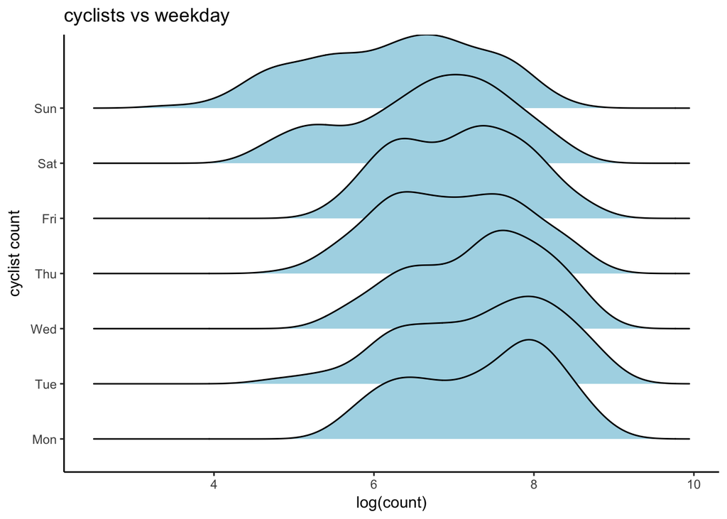

```r
ggplot(df_tr, aes(x = log(count), y = wkday)) +
  geom_density_ridges(fill = "lightblue", bandwidth = 0.29) +
  labs(y = "cyclist count", title = "cyclists vs weekday") + theme_classic()
```

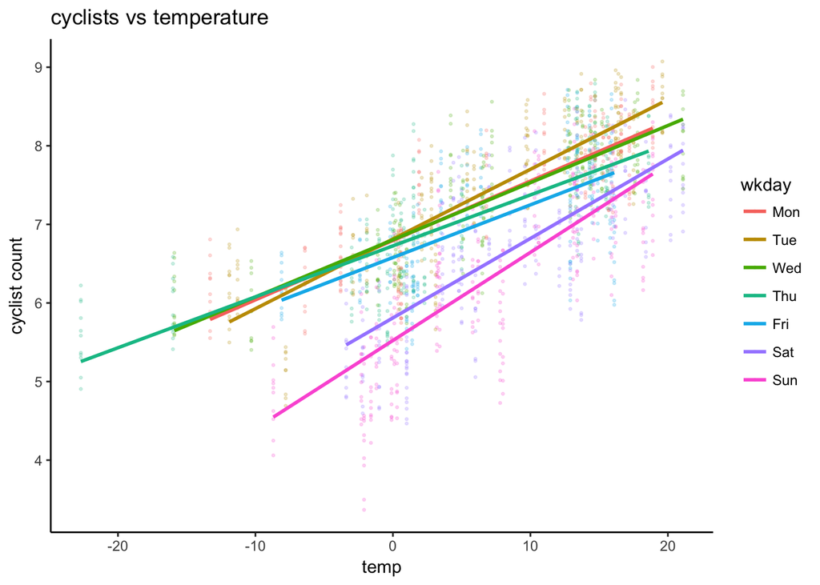

```r
ggplot(df_tr, aes(x = temp, y = log(count), color = wkday)) +
  geom_point(size = 0.5, alpha = 0.2) +
  geom_smooth(method = "lm", se = FALSE) +
  labs(y = "cyclist count", title = "cyclists vs temperature") + theme_classic()
```

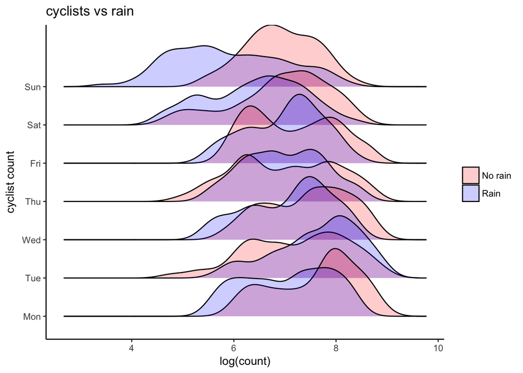

```r
ggplot(df_tr, aes(x = log(count), y = wkday, fill = ifelse(rain == 0, "No rain", "Rain"))) +
  geom_density_ridges(bandwidth = 0.23, alpha = 0.2) +
  labs(y = "cyclist count", title = "cyclists vs rain") +
  theme_classic() +
  scale_fill_manual(values = c("red", "blue")) +
  theme(strip.background = element_blank(), legend.title = element_blank())
```

There seems to be a weekday effect. Also a clear temperature effect which might even vary daily (or be different for weekends and weekdays). There seems to be a difference in cyclist count when it rains and when it does not rain.

# Model

Based on the previous observations, a sensible model might be a linear multilevel model, where effects of rain and temperature vary by weekday. In addition, each station and weekday have separate intercepts. This means $$
$$\begin{aligned}
y &\sim N(\mu_y, \sigma_y) \\
\mu_y &= \alpha^{(0)} + \alpha^{(1)}_{station[n]} + \alpha^{(2)}_{wkday[n]} + \alpha^{(3)}_{wkday[n]}I[x_{rain}>0] + \beta_{wkday[n]}x_{temp},\ & n\in1:N \\
\alpha^{(0)} &\sim N(\mu_d, 2*\sigma_d) \\
\alpha^{(1)}_j &\sim N(0, \sigma_{a\_station}),\ & j \in 1:J_{station}\\
\alpha^{(2)} &\sim N(0, \sigma_{a\_wkday}),\ & j \in 1:J_{wkday} \\
\alpha^{(3)} &\sim N(\mu_{rain}, \sigma_{a\_rain}),\ & j \in 1:J_{wkday} \\
\beta &\sim N(\mu_{temp}, \sigma_{b\_temp}),\ & j \in 1:J_{wkday} \\
\sigma_y, \sigma_{a\_station}, \sigma_{a\_wkday}, &\sim C^+(0, 2.5)\\
\sigma_{a\_rain}, \sigma_{b\_temp} &~ \sim N(0, 0.5) \\
\mu_{rain}, \mu_{temp} &\sim N(0, 1),
\end{aligned}$$

$$ where $y$ is the log-count of cyclists, $\alpha^(0)$ is the common intercept, $\alpha^{(1)}_j$ the intercept for each weekday, $\alpha^{(2)}_j$ the intercept for each weekday, $\alpha^{(2)}_j$ the effect of rain for each weekday and $\beta_j$ a coefficient for the effect of temperature for each weekday. The intercept is given a normal prior with mean $\mu_d$ (the mean of the (training) data) and standard deviation $\sigma_d$ (the sd of the data) to help the sampler identify the mean component.

The priors for $\sigma_{a\_rain}$ and $\sigma_{b\_temp}$ are quite tight as it is not likely that the effect of 1 degrees increase in temperature or the effect of rain for any particular weekday is more than 70% increase to the mean effect (although having a (half-)normal prior for a scale parameter could be a problem due to it having so much mass near zero if the data does not separate the effects enough). Also, the corresponding mean parameters have normal priors with scale of one as also the effect of weather (in terms of one degree increase or rain vs no rain) should not be more dramatical than two to three-fold increase in the number of cyclists.

The scale parameters for the other parameters are given very weakly regularizing half-Cauchy priors with a scale of 2.5. Note, that the group means for day-of-the-week effect and station effect are zero centered as they are absorbed to the intercept (although in practice the means are modelled as parameters to improve the efficiency of the sampler as explained in (Gelman and Hill 2007)).

Let’s fit the model.

Depending on the computer, this will take a few minutes.

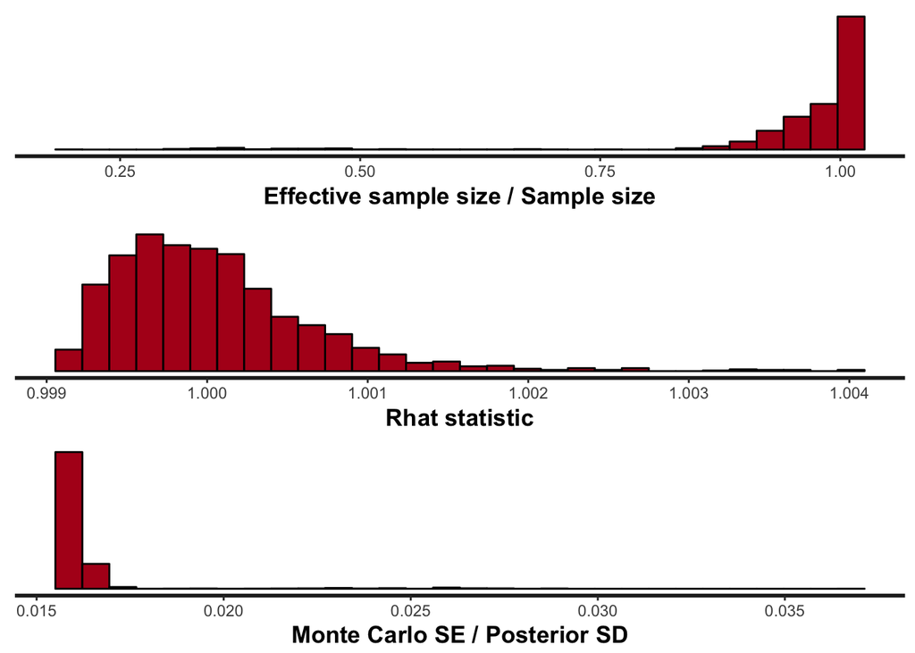

```r
grid.arrange(stan_ess(fit, bins = 30),
             stan_rhat(fit, bins = 30),
             stan_mcse(fit, bins = 30), ncol = 1)
```

Everything seems ok so let’s proceed to posterior predictive checks.

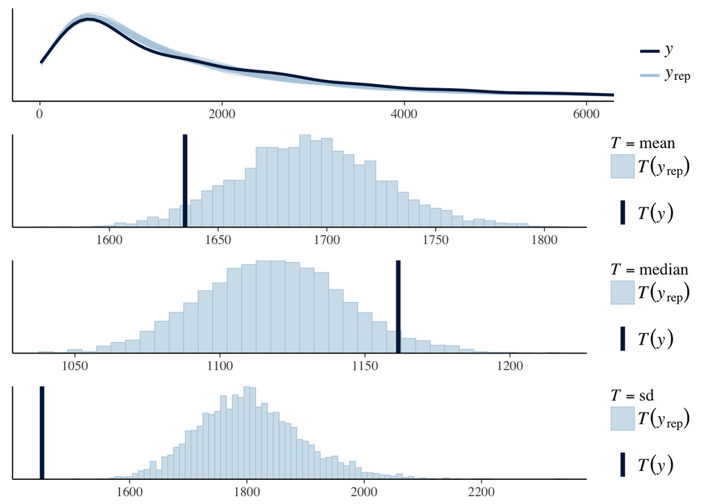

```r
grid.arrange(
  ppc_dens_overlay(y, e$count_sim[sample(4000, 50),]) + coord_cartesian(xlim = c(0, 6000)),
  ppc_stat(y, e$count_sim, stat = "mean", binwidth = 5),
  ppc_stat(y, e$count_sim, stat = "median", binwidth = 5),
  ppc_stat(y, e$count_sim, stat = "sd", binwidth = 10), ncol = 1)
```

Seems like in general the model is pretty OK, but not exactly as good as it probably could be. Especially the standard deviation seems to be overestimated quite a lot, which likely related to the transformed scale, but still ideally should not be as severe. Possibly this should be investigated further?

Let’s check the model fit also on test data. For comparability the same periods are used as with [GPs](https://github.com/paasim/baana-gp).

```r
posterior_pred <- function(df, lq = 0.05, uq = 0.95) {

  # transform factor to a matrix of indicators and multiply them by val
  expand_pred <- function(inds, val) t(model.matrix(~inds - 1) * val)

  mu <- c(e$a) +
          (e$a_station %*% expand_pred(df$station, 1)) +
          (e$a_wkday %*% expand_pred(df$wkday, 1)) +
          (e$a_rain %*% expand_pred(df$wkday, df$rain > 0)) +
          (e$b_temp %*% expand_pred(df$wkday, df$temp))
  y <- (mu + rnorm(length(mu)) * c(e$sig_y)) %>%
    exp()

  tibble(date = df$date,
         mean = colMeans(y),
         lq = apply(y, 2, . %>% quantile(., lq)),
         uq = apply(y, 2, . %>% quantile(., uq)))
}

cond_s15 <- quo(station == "baana" & date >= "2015-06-19" & date <= "2015-08-23")
cond_w16 <- quo(station == "baana" & date >= "2015-11-11" & date <= "2016-01-15")

yp_s15 <- posterior_pred(filter(df, eval(cond_s15)))
yp_w16 <- posterior_pred(filter(df, eval(cond_w16)))
```

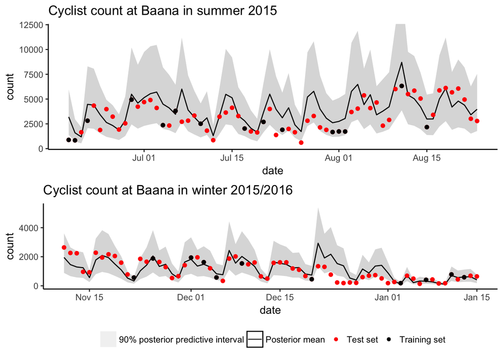

```r
p_s15 <- ggplot(yp_s15, aes(x = date)) +
  geom_line(aes(y = mean, col = "Posterior mean")) +
  geom_ribbon(aes(ymin = lq, ymax = uq,
                  col = "90% posterior predictive interval"), alpha = 0.2) +
  geom_point(aes(y = count, col = "Test set"), filter(df, eval(cond_s15))) +
  geom_point(aes(y = count, col = "Training set"), filter(df_tr, eval(cond_s15))) +
  scale_color_manual(name = "", values = c("Posterior mean" = "black",
                                           "Training set" = "black",
                                           "Test set" = "red",
                                           "90% predictive interval" = "gray")) +
  labs(y = "count", title = "Cyclist count at Baana in summer 2015") +
  coord_cartesian(ylim = c(500, 12000)) + guides(color = FALSE) +
  theme_classic() + theme(legend.position = "bottom")
p_w16 <- ggplot(yp_w16, aes(x = date)) +
  geom_line(aes(y = mean, col = "Posterior mean")) +
  geom_ribbon(aes(ymin = lq, ymax = uq,
                  col = "90% posterior predictive interval"), alpha = 0.2) +
  geom_point(aes(y = count, col = "Test set"), filter(df, eval(cond_w16))) +
  geom_point(aes(y = count, col = "Training set"), filter(df_tr, eval(cond_w16))) +
  scale_color_manual(name = "", values = c("Posterior mean" = "black",
                                           "Training set" = "black",
                                           "Test set" = "red",
                                           "90% predictive interval" = "gray")) +
  theme_classic() + theme(legend.position = "bottom") +
  labs(y = "count", title = "Cyclist count at Baana in winter 2015/2016") +
  guides(color = guide_legend(override.aes=list(
    shape=c(NA, NA, 16, 16), linetype = c(1, 1, 0, 0),
    fill = c("gray", rep("white", 3)))))

grid.arrange(p_s15, p_w16)
```

Seems like the model fits to the data quite well and it seems to be able to identify the relevant patterns in the data. On the other hand, the variance seems quite high during the summer suggesting that there is likely some room for improvement.

A numerical check for the calibration of the model, shows that the predictions are calibrated quite OK

```r
df_test <- filter(df, !(date %in% df_tr$date))
yp_test9 <- posterior_pred(df_test)

map2(c(0.25, 0.125, 0.05), c(0.75, 0.875, 0.95),
          ~posterior_pred(df_test, .x, .y)) %>%
  set_names(c("50%", "75%", "90%")) %>%
  map_dbl(~mean(.x$lq <= df_test$count & .x$uq >= df_test$count))
```

```
##       50%       75%       90%
## 0.4550468 0.7182487 0.8793449
```

# Results

Because the modelling is done on log-scale, all the effects are multiplicative.

Differences between the stations:

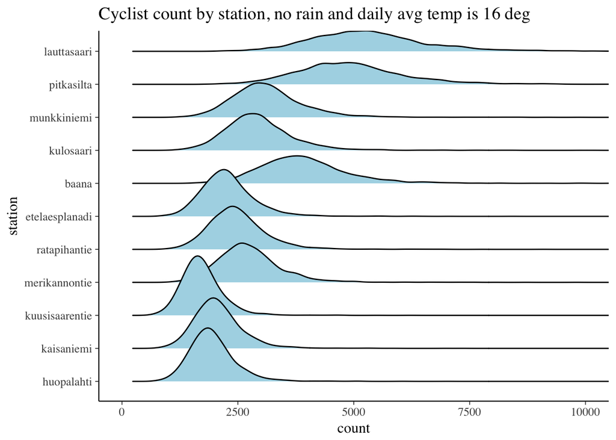

```r
(as_tibble(e$a_station) + e$a + e$mu_b_temp*16) %>%
  set_names(levels(df_tr$station)) %>%
  gather(station, log_count, factor_key = TRUE) %>%
  ggplot(aes(x = exp(log_count), y = station)) +
  geom_density_ridges(fill = "lightblue", bandwidth = 125) +
  coord_cartesian(xlim = c(0, 10000)) +
  labs(x = "count",
       title = "Cyclist count by station, no rain and daily avg temp is 16 deg")
```

There is much more variation on some stations than others. The ones having the most variation also seem to be the most popular routes. Maybe this is related to some construction work? This might also be related to the problems seen in the posterior predictive checks.

Difference between weekdays:

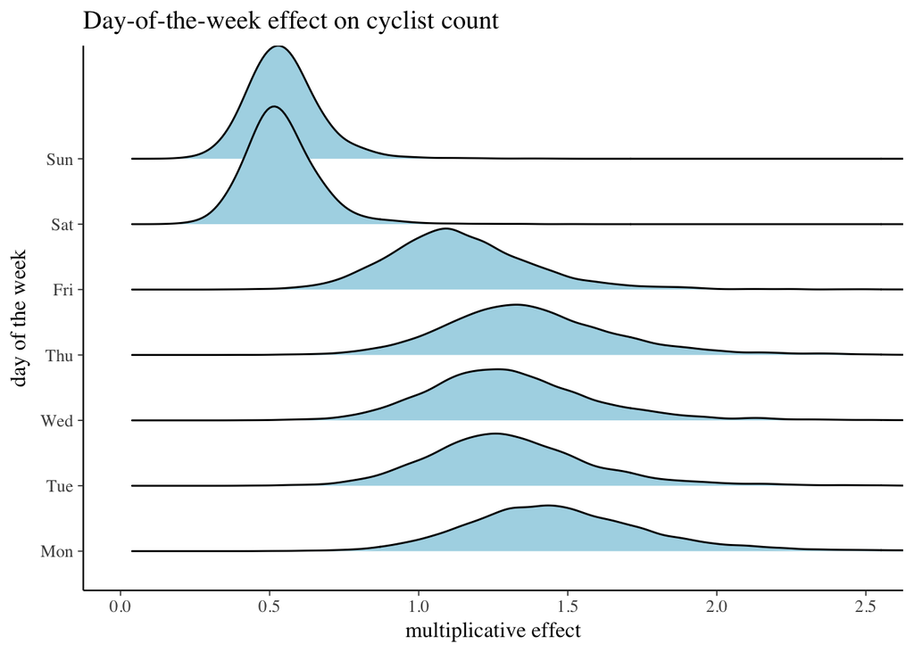

```r
as_tibble(e$a_wkday) %>%
  set_names(levels(df_tr$wkday)) %>%
  gather(wkday, log_count, factor_key = TRUE) %>%
  ggplot(aes(x = exp(log_count), y = wkday)) +
  geom_density_ridges(fill = "lightblue", bandwidth = 0.04) +
  coord_cartesian(xlim = c(0, 2.5)) +
  labs(x = "multiplicative effect", y = "day of the week",
       title = "Day-of-the-week effect on cyclist count")
```

Temperature effect:

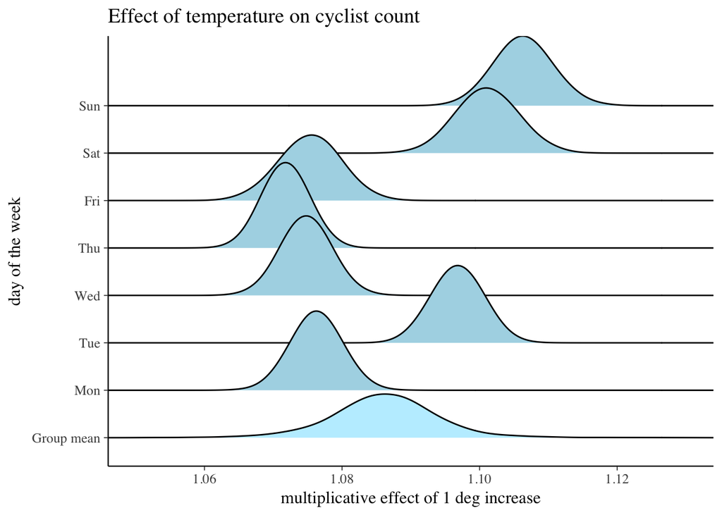

```r
as_tibble(cbind(e$mu_b_temp, e$b_temp)) %>%
  set_names(c("Group mean", levels(df_tr$wkday))) %>%
  gather(wkday, log_count, factor_key = TRUE) %>%
  ggplot(aes(x = exp(log_count), y = wkday, fill = (wkday == "Group mean"))) +
  geom_density_ridges(bandwidth = 0.002) +
  scale_fill_manual(values = c("lightblue", "lightblue1")) +
  guides(fill = FALSE) +
  coord_cartesian(xlim = c(1.05, 1.13)) +
  labs(x = "multiplicative effect of 1 deg increase", y = "day of the week",
       title = "Effect of temperature on cyclist count")
```

Effect of rain:

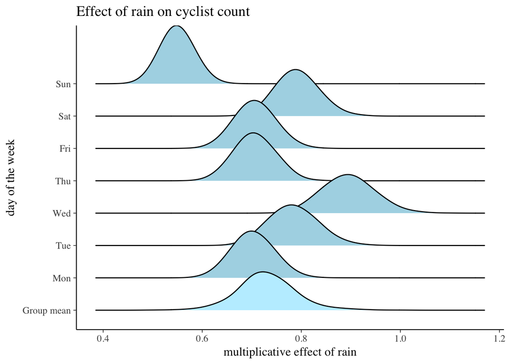

```r
as_tibble(cbind(e$mu_a_rain, e$a_rain)) %>%
  set_names(c("Group mean", levels(df_tr$wkday))) %>%
  gather(wkday, log_count, factor_key = TRUE) %>%
  ggplot(aes(x = exp(log_count), y = wkday, fill = (wkday == "Group mean"))) +
  geom_density_ridges(bandwidth = 0.02) +
  scale_fill_manual(values = c("lightblue", "lightblue1")) +
  guides(fill = FALSE) +
  labs(x = "multiplicative effect of rain", y = "day of the week",
       title = "Effect of rain on cyclist count")
```

# Conclusion

This is still not a conclusive analysis, but seems like fitting multilevel models in stan is also relatively easy and useful.

# References

Finnish Meteorological Institute. 2017. “Kaisaniemi Weather Station Observations.” Licensed under the Creative Commons Attribution 4.0 International license (CC BY 4.0). https://en.ilmatieteenlaitos.fi/open-data.

Gelman, Andrew, and Jennifer Hill. 2007. *Data Analysis Using Regression and Multilevelhierarchical Models*. Vol. 1. Cambridge University Press New York, NY, USA.

HRI, Helsinki Region Infoshare. 2017. “Helsingin Pyöräilijämäärät.” Licensed under the Creative Commons Attribution 4.0 International license (CC BY 4.0). http://www.hri.fi/fi/dataset/helsingin-pyorailijamaarat.

Stan Development Team. 2016. “RStan: The R Interface to Stan.” http://mc-stan.org/.